# Factor Analysis

Hannah Andrews

4/30/2021

Sample: There are 6157 complete cases on CAM variables at Wave 1.

# Describe Data

## Table: Frequencies and percentages on each variable

```
##              Item Category Frequency Percent Pcnt_of_nonMissing
## 1    aAcupuncture        0      6083    98.8               98.8
## 2    aAcupuncture        1        74     1.2                1.2
## 3    aBiofeedback        0      6109    99.2               99.2
## 4    aBiofeedback        1        48     0.8                0.8
## 5   aChiropractic        0      5418    88.0               88.0
## 6   aChiropractic        1       739    12.0               12.0
## 7     aEnergyHeal        0      6064    98.5               98.5
## 8     aEnergyHeal        1        93     1.5                1.5
## 9   aExerciseMove        0      5079    82.5               82.5
## 10  aExerciseMove        1      1078    17.5               17.5
## 11        aHerbal        0      5856    95.1               95.1
## 12        aHerbal        1       301     4.9                4.9
## 13      aVitamins        0      5875    95.4               95.4
## 14      aVitamins        1       282     4.6                4.6
```

[output cut: 16 more lines]

## Visualization of frequencies

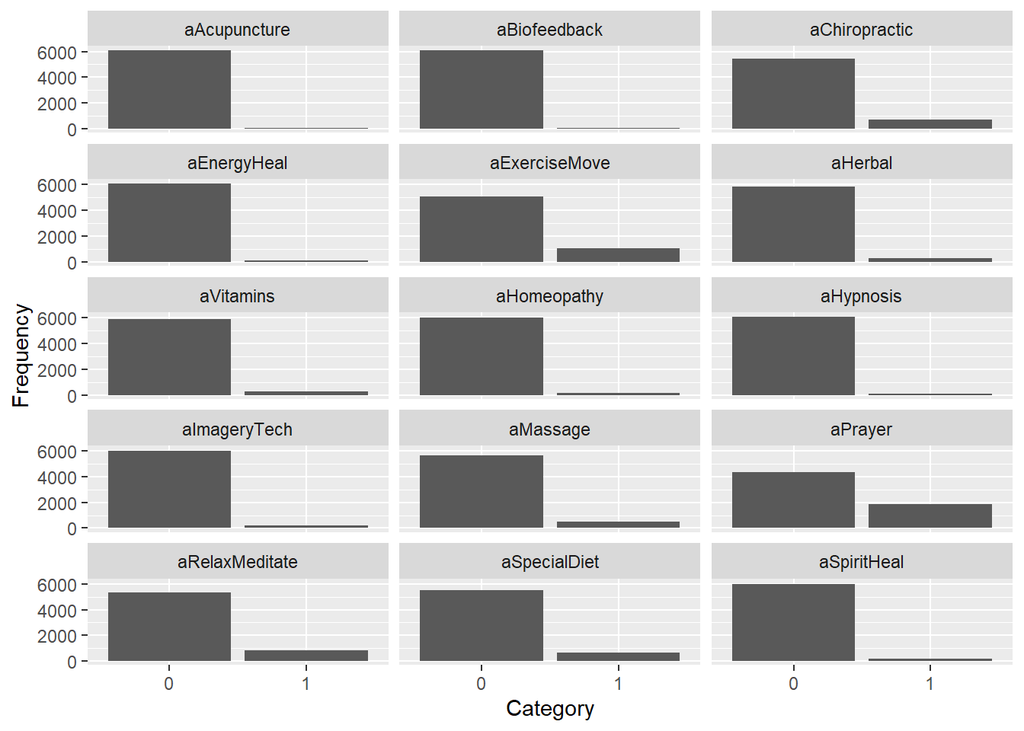

# Correlation matrix Create and plot the tetrachoric correlation matrix for all CAMs.

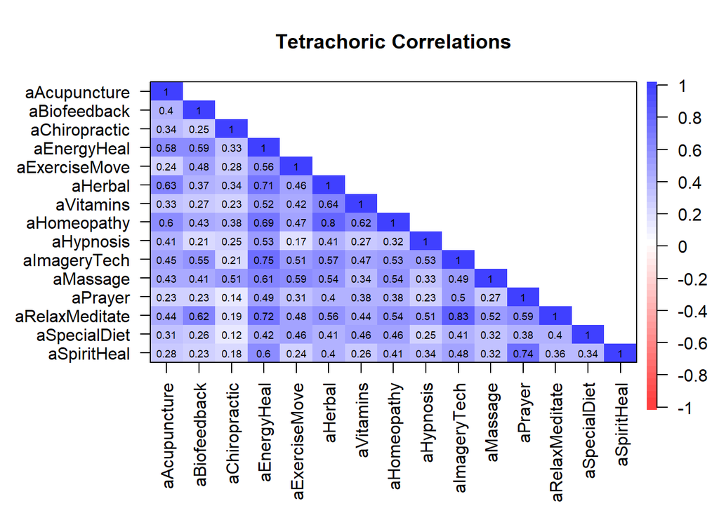

Check that items are not perfectly correlated with each other.

```
##                aA aB aC aEH aEM aHr aV aHm aHy aI aM aP aR aSD aSH
## aAcupuncture   1
## aBiofeedback   .  1
## aChiropractic  .     1
## aEnergyHeal    .  .  .  1
## aExerciseMove     .     .   1
## aHerbal        ,  .  .  ,   .   1
## aVitamins      .        .   .   ,   1
## aHomeopathy    .  .  .  ,   .   ,   ,  1
## aHypnosis      .        .       .      .   1
## aImageryTech   .  .     ,   .   .   .  .   .   1
## aMassage       .  .  .  ,   .   .   .  .   .   .  1
## aPrayer                 .   .   .   .  .       .     1
## aRelaxMeditate .  ,     ,   .   .   .  .   .   +  .  .  1
## aSpecialDiet   .        .   .   .   .  .       .  .  .  .  1
## aSpiritHeal             .       .      .   .   .  .  ,  .  .   1
## attr(,"legend")
## [1] 0 ' ' 0.3 '.' 0.6 ',' 0.8 '+' 0.9 '*' 0.95 'B' 1
```

# Test for correlation adequacy

I will test for correlation adequacy using Bartlett’s Sphericity test. This test tests the hypothesis that correlations between variables are greater than would be expected by chance. The null hypothesis states that all off diagonal are 0. If the null hypothesis is rejected there is correlation adequacy.

```
## $chisq
## [1] 66329.56
##
## $p.value
## [1] 0
##
## $df
## [1] 105
```

I reject the null hypothesis. The CAM items are adequately correlated.

# Test for sampling adequacy

MSA cutoffs: >.9 marvelous, .8s meritorious, .7s middling, .6s mediocre, .5s miserable, less than .5 is unacceptable.

```
## Kaiser-Meyer-Olkin factor adequacy
## Call: KMO(r = het.mat)
## Overall MSA =  0.76
## MSA for each item =
##   aAcupuncture   aBiofeedback  aChiropractic    aEnergyHeal  aExerciseMove
##           0.85           0.75           0.73           0.89           0.77
##        aHerbal      aVitamins    aHomeopathy      aHypnosis   aImageryTech
##           0.91           0.81           0.88           0.72           0.82
##       aMassage        aPrayer aRelaxMeditate   aSpecialDiet    aSpiritHeal
##           0.81           0.53           0.64           0.88           0.51
```

Items that may be a concern with regard to sampling adequacy: prayer or other spiritual practices, relaxation or meditation, and spiritual healing. Overall MSA indicates sampling adequacy.

# Determining the number of factors

First, I will run a parallel analysis. From RDocumentation: “``Parallel” analyis is a technique that compares the scree of factors of the observed data with that of a random data matrix of the same size as the original."

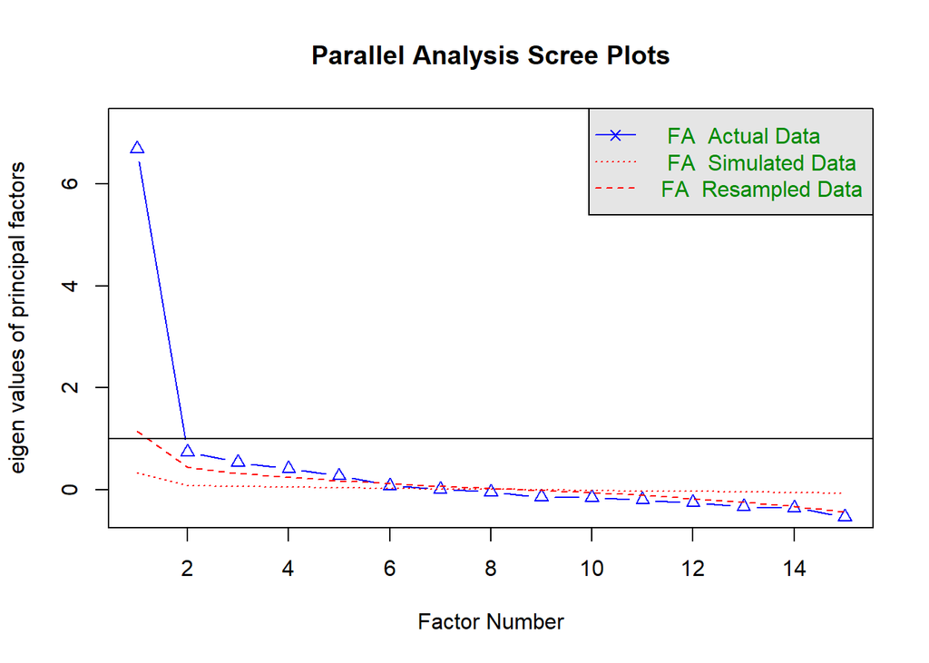

```
## Parallel analysis suggests that the number of factors =  6  and the number of components =  NA
```

I received many warning messages stating “A cell entry of 0 was replaced with correct = 0.5. Check your data!” This has to do with continuity when computing a tetrachoric correlation matrix. I added 1 to all values in the dataframe to check that the issue was not the 0/1 values. The results were the same.

From Statistics of DOOM notes: i. The dark line is set at one, which is part of the Kaiser criterion. This method is an older rule of thumb that is not well supported anymore. You would look at the number of eigenvalues that are greater than 1 (or .70 in new literature). This rule tends to overestimate the number of factors/components needed. ii. The red dotted line is the random data set used to test this analysis. Your data is randomly reordered to see how many factors are better than chance. iii. The blue line and triangles are your eigenvalues from the real dataset. iv. You want to look at where the blue and red lines cross.

Note: Scree plots are a visual depiction of the eigenvalues. Look for the large drop off to figure out how many factors to use.

# Kaiser Criterion

```r
# older kaiser criterion, number of eigenvalues greater than 1
sum(nofactors$fa.values > 1.0)
```

```
## [1] 1
```

```r
# new kaiser criterion, number of eigenvalues greater than 0.7
sum(nofactors$fa.values > .7)
```

```
## [1] 2
```

New kaiser criterion rule (eigenvalues greater than 0.7) suggests 2 factors.

# 2-6 Factor Models with all CAM variables

All models run using oblique rotation (factors are allowed to correlate when rotated) and maximum likelihood estimation.

## Factor loadings: 2 Factor model with all CAM variables

```
##
## Loadings:
##                ML2    ML1
## aAcupuncture    0.719 -0.131
## aBiofeedback    0.672 -0.106
## aChiropractic   0.448
## aEnergyHeal     0.872
## aExerciseMove   0.618
## aHerbal         0.810
## aVitamins       0.559  0.105
## aHomeopathy     0.804
## aHypnosis       0.565
## aImageryTech    0.728  0.140
## aMassage        0.741 -0.104
## aPrayer                1.007
## aRelaxMeditate  0.647  0.272
## aSpecialDiet    0.415  0.174
## aSpiritHeal     0.185  0.648
##
##                  ML2   ML1
## SS loadings    5.949 1.622
## Proportion Var 0.397 0.108
## Cumulative Var 0.397 0.505
```

All items only load onto one factor.

Ml1 includes spiritual healing and prayer. All other items load onto ML2.

The factors are correlated (r = 0.51).

## Factor Loadings: 3 Factor model all CAM variables

```
##
## Loadings:
##                ML3    ML1    ML2
## aAcupuncture    0.679
## aBiofeedback    0.228  0.509
## aChiropractic   0.532 -0.144
## aEnergyHeal     0.548  0.275  0.245
## aExerciseMove   0.473  0.204
## aHerbal         0.878
## aVitamins       0.653
## aHomeopathy     0.871
## aHypnosis       0.188  0.343  0.122
## aImageryTech    0.192  0.658  0.140
## aMassage        0.554  0.170
## aPrayer        -0.132  0.424  0.637
## aRelaxMeditate         0.992
## aSpecialDiet    0.357  0.126  0.135
## aSpiritHeal                   0.998
##
##                  ML3   ML1   ML2
## SS loadings    3.807 2.167 1.528
## Proportion Var 0.254 0.144 0.102
## Cumulative Var 0.254 0.398 0.500
```

Prayer loads onto two factors (ML1 and ML2). ML1: prayer, biofeedback, hypnosis, imagery techniques, meditation ML2: prayer and spiritual healing ML3: special diet, acupuncture, chiropractice, energy healing, exercise/movement, herbal, vitamins, homeopathy, and massage

## Factor Loadings: 4 Factor model all CAM variables

```
##
## Loadings:
##                ML4    ML2    ML1    ML3
## aAcupuncture    0.594  0.105        -0.124
## aBiofeedback           0.638        -0.164
## aChiropractic   0.492 -0.107
## aEnergyHeal     0.410  0.405  0.311 -0.131
## aExerciseMove   0.467  0.203
## aHerbal         0.886
## aVitamins       0.772        -0.135  0.191
## aHomeopathy     0.859
## aHypnosis              0.505  0.223 -0.220
## aImageryTech           0.759  0.163
## aMassage        0.443  0.273        -0.139
## aPrayer                0.176  0.323  0.729
## aRelaxMeditate         0.992 -0.110  0.166
## aSpecialDiet    0.392                0.119
## aSpiritHeal                   0.960  0.110
##
##                  ML4   ML2   ML1   ML3
## SS loadings    3.470 2.568 1.251 0.758
## Proportion Var 0.231 0.171 0.083 0.051
## Cumulative Var 0.231 0.403 0.486 0.536
```

Energy healing loads on three factors. Prayer loads on two factors. ML1: prayer, energy healing, spirit healing ML2: energy healing, biofeedback, hypnosis, imagery techniques, meditation ML3: prayer ML4: Acupuncture, Chiropractic, Exercise, Herbal, Vitamins, Homeopathy, Massage, Special Diet

## Factor Loadings: 5 Factor model all CAM variables

```
##
## Loadings:
##                ML5    ML3    ML2    ML4    ML1
## aAcupuncture    0.687  0.126 -0.152        -0.107
## aBiofeedback           0.585  0.224        -0.173
## aChiropractic   0.408 -0.114  0.128
## aEnergyHeal     0.351  0.369  0.146  0.324 -0.132
## aExerciseMove                 0.985
## aHerbal         0.902
## aVitamins       0.703         0.101 -0.132  0.198
## aHomeopathy     0.831
## aHypnosis       0.140  0.503 -0.170  0.212 -0.210
## aImageryTech           0.716  0.116  0.173
## aMassage        0.275  0.207  0.350  0.103 -0.150
## aPrayer                0.188         0.317  0.727
## aRelaxMeditate         0.971        -0.109  0.168
## aSpecialDiet    0.248         0.279  0.102  0.111
## aSpiritHeal                          0.964  0.106
##
##                  ML5   ML3   ML2   ML4   ML1
## SS loadings    2.926 2.300 1.337 1.265 0.750
## Proportion Var 0.195 0.153 0.089 0.084 0.050
## Cumulative Var 0.195 0.348 0.438 0.522 0.572
```

Diet doesn’t load on any factors Prayer loads on two factors. Energy healing loads on three factors.

ML1: Prayer ML2: Exercise and massage ML3: Energy, Biofeedback, Hypnosis, ImageryTech, RelaxMeditate ML4: prayer, energy, spiritual healing ML5: Acupuncture, Chiropractic, Herbal, Vitamins, Homeopathy

## Factor Loadings: 6 Factor model all CAM variables

```
##
## Loadings:
##                ML5    ML3    ML2    ML4    ML6    ML1
## aAcupuncture    0.555  0.145 -0.176         0.230
## aBiofeedback           0.578  0.212               -0.147
## aChiropractic   0.100 -0.120                0.672
## aEnergyHeal     0.318  0.375  0.134  0.337        -0.124
## aExerciseMove                 0.961
## aHerbal         0.857
## aVitamins       0.776         0.111 -0.107 -0.136  0.135
## aHomeopathy     0.761                       0.111
## aHypnosis       0.117  0.501 -0.174  0.223        -0.194
## aImageryTech    0.108  0.704  0.125  0.191
## aMassage               0.201  0.278         0.532
## aPrayer                0.163         0.272         0.758
## aRelaxMeditate         0.946        -0.114         0.193
## aSpecialDiet    0.336         0.290  0.121 -0.153
## aSpiritHeal                          0.949         0.128
##
##                  ML5   ML3   ML2   ML4   ML6   ML1
## SS loadings    2.484 2.226 1.239 1.224 0.876 0.745
## Proportion Var 0.166 0.148 0.083 0.082 0.058 0.050
## Cumulative Var 0.166 0.314 0.397 0.478 0.537 0.586
```

Energy healing loads on 3 factors. Prayer and exercise are only items to load on their factors.

## Diagrams of factor loadings

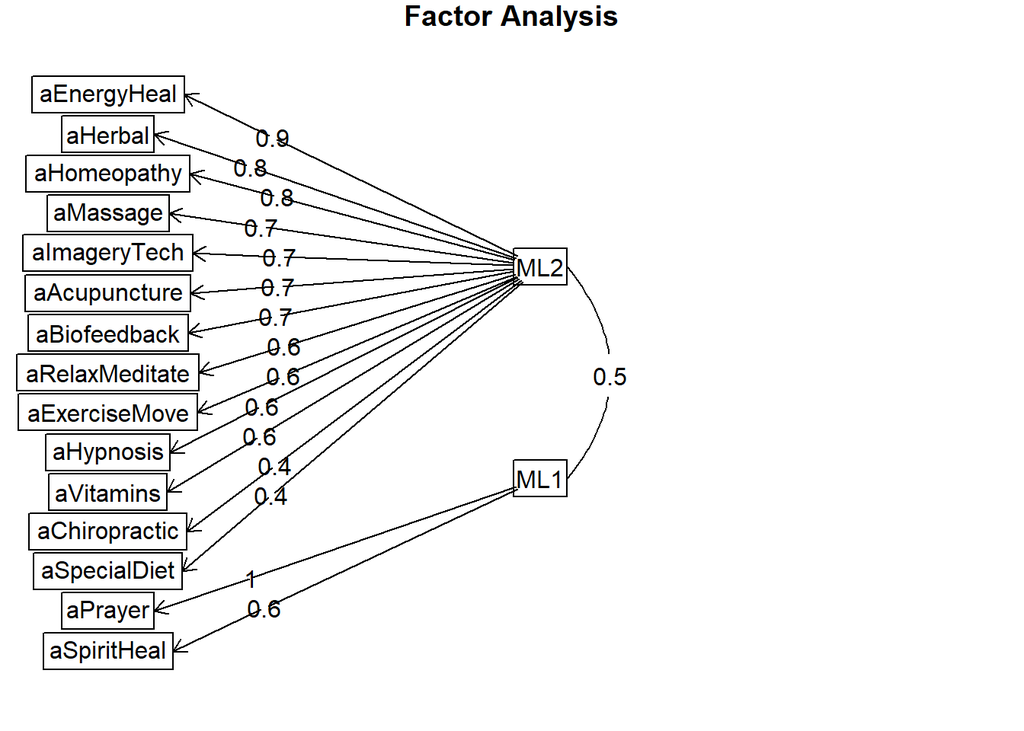

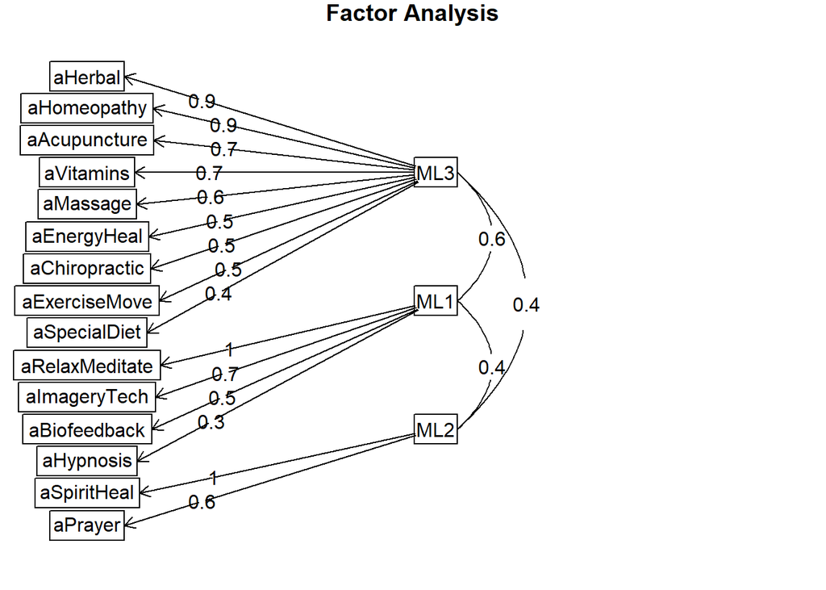

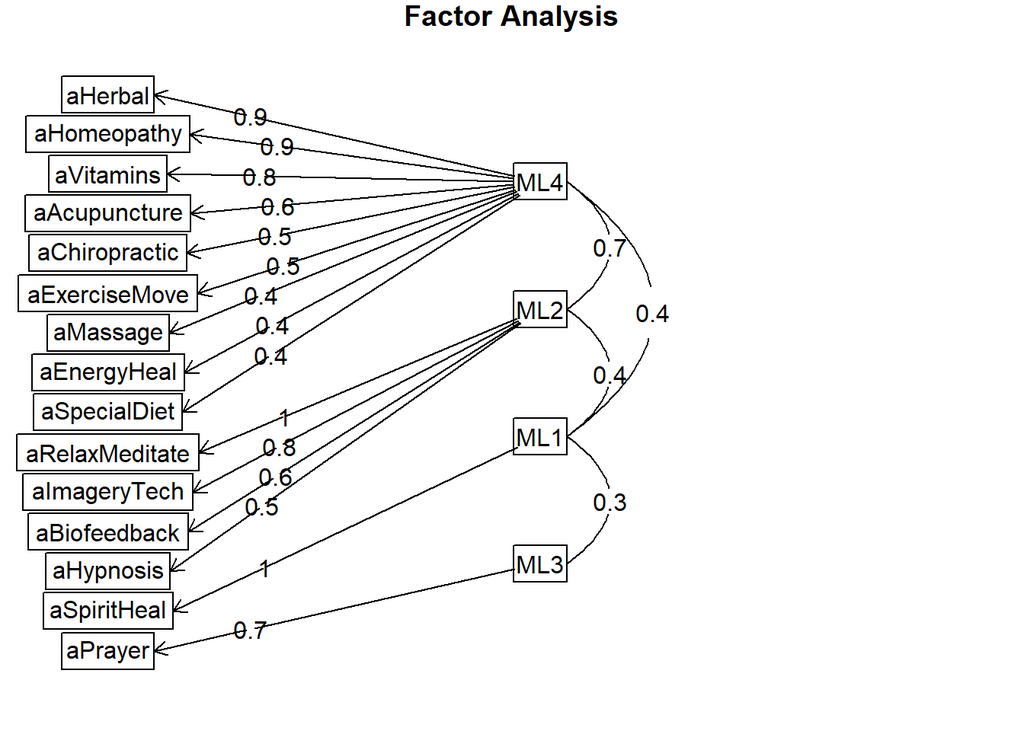

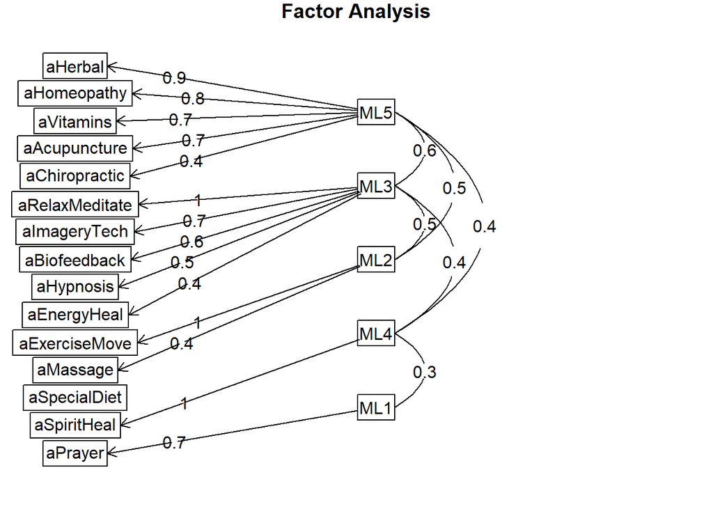

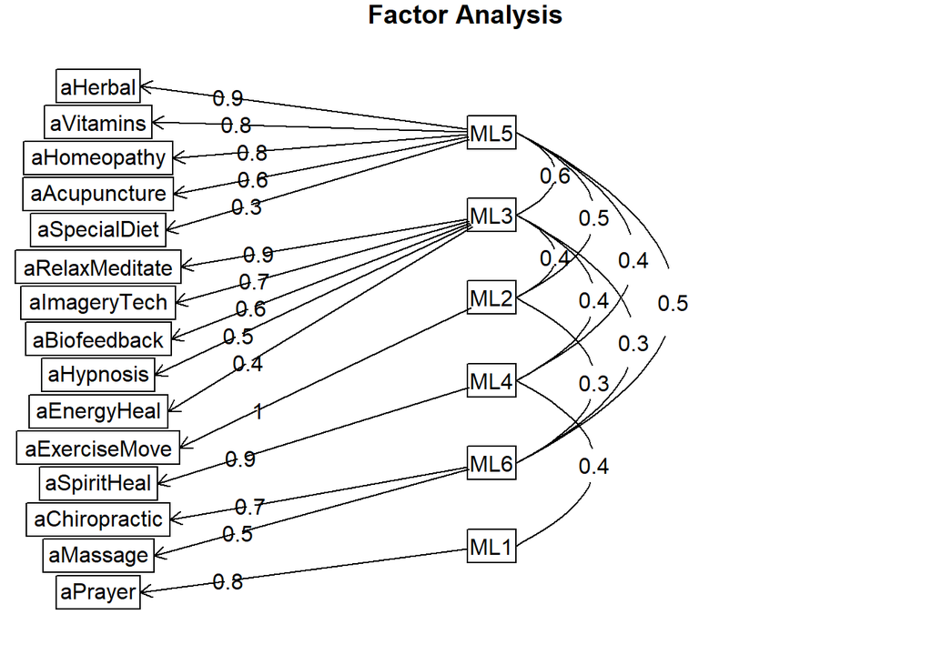

```
##                  Model       TLI       BIC       RMSR     RMSEA
## 2 Factor Model Model 1 0.6147528 17875.291 0.07479222 0.1986336
## 3 Factor Model Model 2 0.7101065 11028.394 0.06324245 0.1722974
## 4 Factor Model Model 3 0.7615625  7272.309 0.05559871 0.1562511
## 5 Factor Model Model 4 0.8052751  4600.918 0.04192812 0.1411962
## 6 Factor Model Model 5 0.8210908  3151.229 0.02896826 0.1353333
##                RMSEA_lower_bound RMSEA_upper_bound RMSEA_confidence       CFI
## 2 Factor Model         0.1962480         0.2010624              0.9 0.7212149
## 3 Factor Model         0.1696741         0.1749637              0.9 0.8261205
## 4 Factor Model         0.1533336         0.1592143              0.9 0.8842378
## 5 Factor Model         0.1379007         0.1445433              0.9 0.9258594
## 6 Factor Model         0.1315285         0.1392000              0.9 0.9489164
```

## Reliability

```
##
## Reliability analysis
## Call: psych::alpha(x = acams[, ML2])
##
##   raw_alpha std.alpha G6(smc) average_r S/N    ase  mean   sd median_r
##       0.68      0.71    0.71      0.16 2.5 0.0055 0.063 0.11     0.16
##
##  lower alpha upper     95% confidence boundaries
## 0.67 0.68 0.69
##
##  Reliability if an item is dropped:
##                raw_alpha std.alpha G6(smc) average_r S/N alpha se  var.r med.r
## aAcupuncture        0.68      0.71    0.71      0.17 2.4   0.0057 0.0077  0.16
## aBiofeedback        0.68      0.71    0.71      0.17 2.5   0.0057 0.0072  0.17
## aChiropractic       0.69      0.71    0.71      0.17 2.5   0.0054 0.0072  0.17
## aEnergyHeal         0.66      0.68    0.68      0.15 2.2   0.0059 0.0072  0.14
## aExerciseMove       0.66      0.69    0.69      0.16 2.2   0.0061 0.0074  0.15
## aHerbal             0.65      0.68    0.67      0.15 2.1   0.0061 0.0062  0.15
## aVitamins           0.66      0.70    0.70      0.16 2.3   0.0059 0.0075  0.15
## aHomeopathy         0.66      0.69    0.68      0.15 2.2   0.0059 0.0068  0.15
## aHypnosis           0.68      0.72    0.72      0.17 2.5   0.0056 0.0070  0.17
## aImageryTech        0.66      0.69    0.68      0.15 2.2   0.0060 0.0069  0.14
## aMassage            0.65      0.69    0.69      0.15 2.2   0.0062 0.0074  0.15
## aRelaxMeditate      0.64      0.68    0.68      0.15 2.1   0.0063 0.0068  0.14
## aSpecialDiet        0.67      0.70    0.70      0.16 2.4   0.0057 0.0077  0.16
##
##  Item statistics
##                   n raw.r std.r r.cor r.drop   mean    sd
## aAcupuncture   6157  0.29  0.39  0.29   0.22 0.0120 0.109
## aBiofeedback   6157  0.25  0.35  0.23   0.19 0.0078 0.088
## aChiropractic  6157  0.43  0.36  0.25   0.21 0.1200 0.325
## aEnergyHeal    6157  0.47  0.56  0.51   0.39 0.0151 0.122
## aExerciseMove  6157  0.61  0.50  0.43   0.39 0.1751 0.380
## aHerbal        6157  0.56  0.60  0.57   0.44 0.0489 0.216
## aVitamins      6157  0.45  0.46  0.38   0.32 0.0458 0.209
## aHomeopathy    6157  0.48  0.54  0.50   0.39 0.0231 0.150
## aHypnosis      6157  0.24  0.33  0.21   0.16 0.0117 0.108
## aImageryTech   6157  0.50  0.54  0.50   0.40 0.0299 0.170
## aMassage       6157  0.58  0.53  0.47   0.42 0.0843 0.278
## aRelaxMeditate 6157  0.62  0.58  0.54   0.43 0.1320 0.339
## aSpecialDiet   6157  0.49  0.42  0.33   0.29 0.1087 0.311
##
## Non missing response frequency for each item
##                   0    1 miss
## aAcupuncture   0.99 0.01    0
## aBiofeedback   0.99 0.01    0
## aChiropractic  0.88 0.12    0
## aEnergyHeal    0.98 0.02    0
## aExerciseMove  0.82 0.18    0
## aHerbal        0.95 0.05    0
## aVitamins      0.95 0.05    0
## aHomeopathy    0.98 0.02    0
## aHypnosis      0.99 0.01    0
## aImageryTech   0.97 0.03    0
## aMassage       0.92 0.08    0
## aRelaxMeditate 0.87 0.13    0
## aSpecialDiet   0.89 0.11    0
```

Raw alpha for ML2 is 0.68. This is acceptable.

```
##
## Reliability analysis
## Call: psych::alpha(x = acams[, ML1])
##
##   raw_alpha std.alpha G6(smc) average_r  S/N   ase mean   sd median_r
##       0.29      0.41    0.26      0.26 0.69 0.012 0.17 0.27     0.26
##
##  lower alpha upper     95% confidence boundaries
## 0.27 0.29 0.31
##
##  Reliability if an item is dropped:
##             raw_alpha std.alpha G6(smc) average_r  S/N alpha se var.r med.r
## aPrayer         0.666      0.26   0.065      0.26 0.34       NA     0  0.26
## aSpiritHeal     0.098      0.26   0.065      0.26 0.34       NA     0  0.26
##
##  Item statistics
##                n raw.r std.r r.cor r.drop  mean   sd
## aPrayer     6157  0.95  0.79   0.4   0.26 0.299 0.46
## aSpiritHeal 6157  0.55  0.79   0.4   0.26 0.032 0.18
##
## Non missing response frequency for each item
##                0    1 miss
## aPrayer     0.70 0.30    0
## aSpiritHeal 0.97 0.03    0
```

Raw alpha for ML1 if 0.29. This is unacceptable.

# Run factor model without prayer and spiritual healing

## Tetrachoric correlations (excluding prayer and spiritual healing)

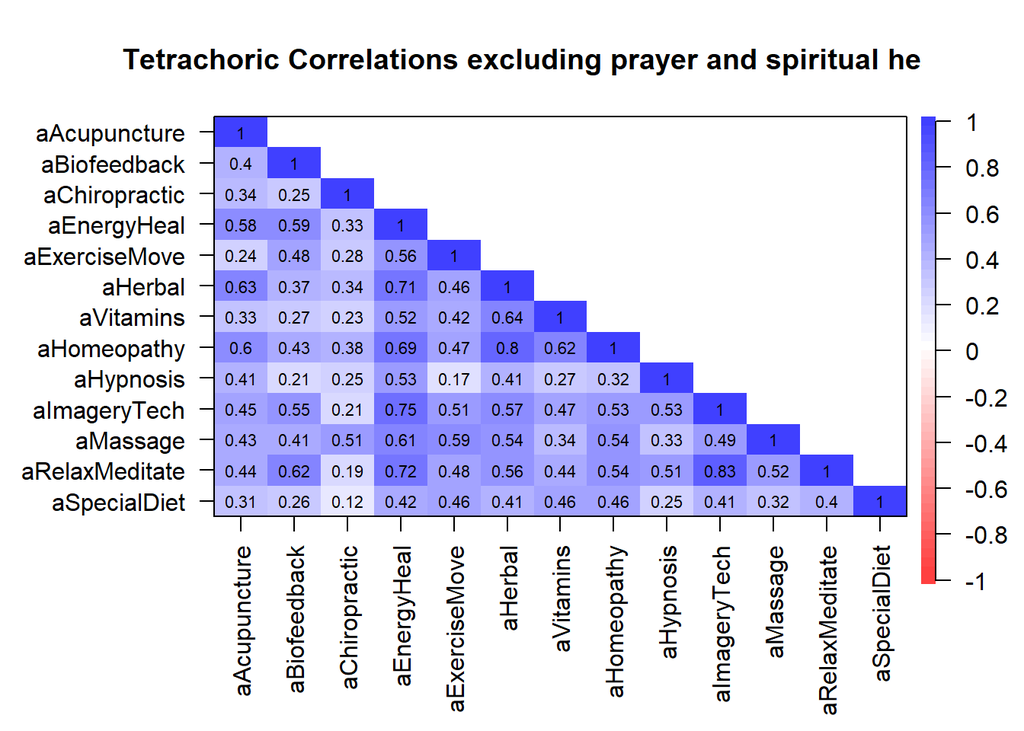

## Test for correlation adequacy

Bartlett’s test for sphericity.

```
## $chisq
## [1] 51305.93
##
## $p.value
## [1] 0
##
## $df
## [1] 78
```

Items are adequately correlated.

## Test for sampling adequacy

MSA cutoffs: >.9 marvelous, .8s meritorious, .7s middling, .6s mediocre, .5s miserable, less than .5 is unacceptable.

```
## Kaiser-Meyer-Olkin factor adequacy
## Call: KMO(r = het.mat13)
## Overall MSA =  0.89
## MSA for each item =
##   aAcupuncture   aBiofeedback  aChiropractic    aEnergyHeal  aExerciseMove
##           0.90           0.86           0.80           0.94           0.86
##        aHerbal      aVitamins    aHomeopathy      aHypnosis   aImageryTech
##           0.90           0.91           0.91           0.85           0.89
##       aMassage aRelaxMeditate   aSpecialDiet
##           0.88           0.86           0.89
```

All variables meet requirements for sampling adequacy.

## Determining number of factors

### Parallel Analysis

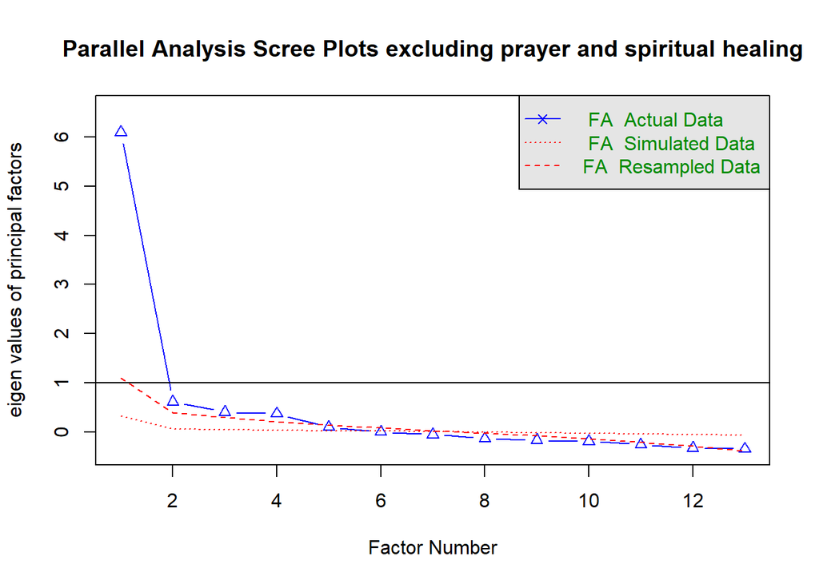

```
## Parallel analysis suggests that the number of factors =  5  and the number of components =  NA
```

The parallel analysis suggests 5 factors. There is a drop off on the scree plot after 4.

### Kaiser Criterion

```r
# older kaiser criterion, number of eigenvalues greater than 1
sum(nofactors13$fa.values > 1.0)
```

```
## [1] 1
```

```r
# new kaiser criterion, number of eigenvalues greater than 0.7
sum(nofactors13$fa.values > .7)
```

```
## [1] 1
```

The Kaiser criterion suggests there is only 1 factor. The Kaiser criterion tends to over estimate factors. Doesn’t seem good that it’s only estimating 1.

## Factor Loadings: 3 factor model excluding prayer and spiritual healing

```
##
## Loadings:
##                ML3    ML1    ML2
## aAcupuncture    0.585
## aBiofeedback           0.582  0.131
## aChiropractic   0.201 -0.200  0.532
## aEnergyHeal     0.370  0.484  0.139
## aExerciseMove          0.265  0.416
## aHerbal         0.892
## aVitamins       0.708        -0.118
## aHomeopathy     0.875
## aHypnosis       0.109  0.487
## aImageryTech           0.910
## aMassage                      0.923
## aRelaxMeditate         0.905
## aSpecialDiet    0.360  0.207
##
##                  ML3   ML1   ML2
## SS loadings    2.734 2.626 1.367
## Proportion Var 0.210 0.202 0.105
## Cumulative Var 0.210 0.412 0.517
```

Energy healing loads on two factors.

## Factor Loadings: 4 factor model excluding prayer and spiritual healing

```
##
## Loadings:
##                ML1    ML3    ML2    ML4
## aAcupuncture    0.188  0.491 -0.203  0.291
## aBiofeedback    0.555         0.204  0.138
## aChiropractic          0.132  0.116  0.580
## aEnergyHeal     0.514  0.318         0.154
## aExerciseMove                 0.852
## aHerbal                0.850
## aVitamins              0.750  0.114 -0.217
## aHomeopathy            0.821         0.105
## aHypnosis       0.597        -0.241  0.133
## aImageryTech    0.894
## aMassage        0.178         0.339  0.507
## aRelaxMeditate  0.919
## aSpecialDiet    0.106  0.397  0.273 -0.179
##
##                  ML1   ML3   ML2   ML4
## SS loadings    2.668 2.501 1.095 0.844
## Proportion Var 0.205 0.192 0.084 0.065
## Cumulative Var 0.205 0.398 0.482 0.547
```

Massage and energy heal load on two factors.

## Factor loadings: 5 factor model excluding prayer and spiritual healing

```
##
## Loadings:
##                ML2    ML3    ML4    ML1    ML5
## aAcupuncture    0.504                0.148 -0.378
## aBiofeedback                         0.982
## aChiropractic   0.139 -0.182  0.536        -0.164
## aEnergyHeal     0.345  0.411  0.165  0.155
## aExerciseMove   0.157         0.427  0.151  0.445
## aHerbal         0.827
## aVitamins       0.740                       0.224
## aHomeopathy     0.839
## aHypnosis              0.668        -0.167 -0.263
## aImageryTech           0.852
## aMassage                      0.908
## aRelaxMeditate         0.745         0.191
## aSpecialDiet    0.415  0.158                0.282
##
##                  ML2   ML3   ML4   ML1   ML5
## SS loadings    2.529 1.989 1.354 1.120 0.585
## Proportion Var 0.195 0.153 0.104 0.086 0.045
## Cumulative Var 0.195 0.348 0.452 0.538 0.583
```

Exercise/movement and energy healing load on two factors

## Compare model fit for 3, 4, and 5 factor models excluding prayer and spiritual healing

```
##                  Model       TLI      BIC       RMSR      RMSEA
## 3 Factor Model Model 1 0.8381332 4139.058 0.05095690 0.13138001
## 4 Factor Model Model 2 0.8803216 2266.929 0.03003509 0.11296260
## 5 Factor Model Model 3 0.9109208 1167.187 0.02007195 0.09745208
##                RMSEA_lower_bound RMSEA_upper_bound RMSEA_confidence       CFI
## 3 Factor Model        0.12816309         0.1346476              0.9 0.9128694
## 4 Factor Model        0.10927667         0.1167114              0.9 0.9509225
## 5 Factor Model        0.09310654         0.1018849              0.9 0.9737473
```

## Four factor model dropping prayer, spiritual healing, biofeedback, and hypnosis.

```
## Factor Analysis using method =  ml
## Call: fa(r = het.mat3, nfactors = 4, n.obs = nrow(acams11), rotate = "oblimin",
##     fm = "ml")
## Standardized loadings (pattern matrix) based upon correlation matrix
##                  ML1   ML2   ML3   ML4   h2   u2 com
## aAcupuncture    0.33  0.05  0.05 -0.11 0.12 0.88 1.3
## aChiropractic   0.09 -0.06  0.33 -0.04 0.12 0.88 1.2
## aEnergyHeal     0.31  0.30  0.08 -0.07 0.28 0.72 2.2
## aExerciseMove  -0.02  0.06  0.26  0.39 0.32 0.68 1.8
## aHerbal         0.65  0.02  0.02  0.02 0.46 0.54 1.0
## aVitamins       0.35  0.01 -0.09  0.24 0.22 0.78 1.9
## aHomeopathy     0.63 -0.03  0.01  0.00 0.39 0.61 1.0
## aImageryTech   -0.01  0.79 -0.02 -0.01 0.61 0.39 1.0
## aMassage        0.01  0.00  0.74  0.00 0.56 0.44 1.0
## aRelaxMeditate  0.06  0.39  0.12  0.18 0.33 0.67 1.7
## aSpecialDiet    0.09  0.03 -0.04  0.44 0.23 0.77 1.1
##
##                        ML1  ML2  ML3  ML4
## SS loadings           1.28 0.98 0.83 0.54
## Proportion Var        0.12 0.09 0.08 0.05
## Cumulative Var        0.12 0.20 0.28 0.33
## Proportion Explained  0.35 0.27 0.23 0.15
## Cumulative Proportion 0.35 0.62 0.85 1.00
##
##  With factor correlations of
##      ML1  ML2  ML3  ML4
## ML1 1.00 0.44 0.43 0.38
## ML2 0.44 1.00 0.35 0.33
## ML3 0.43 0.35 1.00 0.38
## ML4 0.38 0.33 0.38 1.00
##
## Mean item complexity =  1.4
## Test of the hypothesis that 4 factors are sufficient.
##
## The degrees of freedom for the null model are  55  and the objective function was  1.39 with Chi Square of  8540.37
## The degrees of freedom for the model are 17  and the objective function was  0.01
##
## The root mean square of the residuals (RMSR) is  0.01
## The df corrected root mean square of the residuals is  0.02
##
## The harmonic number of observations is  6157 with the empirical chi square  67.2  with prob <  6.5e-08
## The total number of observations was  6157  with Likelihood Chi Square =  59.08  with prob <  1.5e-06
##
## Tucker Lewis Index of factoring reliability =  0.984
## RMSEA index =  0.02  and the 90 % confidence intervals are  0.015 0.026
## BIC =  -89.26
## Fit based upon off diagonal values = 1
## Measures of factor score adequacy
##                                                    ML1  ML2  ML3   ML4
## Correlation of (regression) scores with factors   0.83 0.83 0.80  0.68
## Multiple R square of scores with factors          0.69 0.69 0.65  0.47
## Minimum correlation of possible factor scores     0.38 0.38 0.29 -0.07
```

### Model fit

#### Goodness of fit statistics

```
## [1] 0.9950414
```

Also great!

#### Residual fit statistics

(RMSR) is 0.01, indicating excellent fit. RMSEA is 0.019, indicating excellent fit.

### Reliability Assessment

```
##
## Reliability analysis
## Call: psych::alpha(x = acams11[, factor1])
##
##   raw_alpha std.alpha G6(smc) average_r S/N    ase  mean  sd median_r
##        0.6      0.61    0.57      0.24 1.6 0.0074 0.029 0.1     0.24
##
##  lower alpha upper     95% confidence boundaries
## 0.59 0.6 0.62
##
##  Reliability if an item is dropped:
##              raw_alpha std.alpha G6(smc) average_r  S/N alpha se  var.r med.r
## aAcupuncture      0.60      0.62    0.56      0.29 1.61   0.0079 0.0064  0.29
## aEnergyHeal       0.56      0.56    0.51      0.24 1.30   0.0084 0.0127  0.24
## aHerbal           0.46      0.49    0.43      0.19 0.96   0.0106 0.0052  0.19
## aVitamins         0.59      0.59    0.53      0.27 1.46   0.0077 0.0074  0.25
## aHomeopathy       0.50      0.51    0.45      0.21 1.05   0.0094 0.0073  0.20
##
##  Item statistics
##                 n raw.r std.r r.cor r.drop  mean   sd
## aAcupuncture 6157  0.43  0.54  0.32   0.24 0.012 0.11
## aEnergyHeal  6157  0.55  0.62  0.45   0.35 0.015 0.12
## aHerbal      6157  0.77  0.72  0.63   0.49 0.049 0.22
## aVitamins    6157  0.66  0.57  0.38   0.32 0.046 0.21
## aHomeopathy  6157  0.67  0.69  0.58   0.46 0.023 0.15
##
## Non missing response frequency for each item
##                 0    1 miss
## aAcupuncture 0.99 0.01    0
## aEnergyHeal  0.98 0.02    0
## aHerbal      0.95 0.05    0
## aVitamins    0.95 0.05    0
## aHomeopathy  0.98 0.02    0
```

```
##
## Reliability analysis
## Call: psych::alpha(x = acams11[, factor2])
##
##   raw_alpha std.alpha G6(smc) average_r S/N  ase  mean   sd median_r
##       0.48      0.57     0.4       0.4 1.3 0.01 0.081 0.22      0.4
##
##  lower alpha upper     95% confidence boundaries
## 0.46 0.48 0.5
##
##  Reliability if an item is dropped:
##                raw_alpha std.alpha G6(smc) average_r  S/N alpha se var.r med.r
## aImageryTech        0.20       0.4    0.16       0.4 0.66       NA     0   0.4
## aRelaxMeditate      0.79       0.4    0.16       0.4 0.66       NA     0   0.4
##
##  Item statistics
##                   n raw.r std.r r.cor r.drop mean   sd
## aImageryTech   6157  0.70  0.84  0.53    0.4 0.03 0.17
## aRelaxMeditate 6157  0.93  0.84  0.53    0.4 0.13 0.34
##
## Non missing response frequency for each item
##                   0    1 miss
## aImageryTech   0.97 0.03    0
## aRelaxMeditate 0.87 0.13    0
```

Raw alpha for factor 2 (imagery techniques and meditation) is 0.48 .

```
##
## Reliability analysis
## Call: psych::alpha(x = acams11[, factor3])
##
##   raw_alpha std.alpha G6(smc) average_r  S/N   ase mean   sd median_r
##        0.4      0.41    0.25      0.25 0.68 0.015  0.1 0.24     0.25
##
##  lower alpha upper     95% confidence boundaries
## 0.37 0.4 0.43
##
##  Reliability if an item is dropped:
##               raw_alpha std.alpha G6(smc) average_r  S/N alpha se var.r med.r
## aChiropractic      0.30      0.25   0.065      0.25 0.34       NA     0  0.25
## aMassage           0.22      0.25   0.065      0.25 0.34       NA     0  0.25
##
##  Item statistics
##                  n raw.r std.r r.cor r.drop  mean   sd
## aChiropractic 6157  0.83  0.79   0.4   0.25 0.120 0.33
## aMassage      6157  0.75  0.79   0.4   0.25 0.084 0.28
##
## Non missing response frequency for each item
##                  0    1 miss
## aChiropractic 0.88 0.12    0
## aMassage      0.92 0.08    0
```

Raw alpha for factor 3 ( chiropractic and massage) is 0.40 .

```
##
## Reliability analysis
## Call: psych::alpha(x = acams11[, factor4])
##
##   raw_alpha std.alpha G6(smc) average_r  S/N   ase mean   sd median_r
##       0.38      0.39    0.24      0.24 0.64 0.015 0.14 0.27     0.24
##
##  lower alpha upper     95% confidence boundaries
## 0.35 0.38 0.41
##
##  Reliability if an item is dropped:
##               raw_alpha std.alpha G6(smc) average_r  S/N alpha se var.r med.r
## aExerciseMove      0.29      0.24   0.058      0.24 0.32       NA     0  0.24
## aSpecialDiet       0.20      0.24   0.058      0.24 0.32       NA     0  0.24
##
##  Item statistics
##                  n raw.r std.r r.cor r.drop mean   sd
## aExerciseMove 6157  0.83  0.79  0.39   0.24 0.18 0.38
## aSpecialDiet  6157  0.74  0.79  0.39   0.24 0.11 0.31
##
## Non missing response frequency for each item
##                  0    1 miss
## aExerciseMove 0.82 0.18    0
## aSpecialDiet  0.89 0.11    0
```